# Inference for categorical data

Last compiled: Nov 24, 2016

This is a derivative of an [OpenIntro](https://www.openintro.org/stat/labs.php) lab, and is released under a [Attribution-NonCommercial-ShareAlike 3.0 United States](https://creativecommons.org/licenses/by-nc-sa/3.0/us/) license.

Complete all **Exercises and Questions**. Submit your knitted html file to [crowdgrader](http://crowdgrader.com).

In August of 2012, news outlets ranging from the [Washington Post](http://www.washingtonpost.com/national/on-faith/poll-shows-atheism-on-the-rise-in-the-us/2012/08/13/90020fd6-e57d-11e1-9739-eef99c5fb285_story.html) to the [Huffington Post](http://www.huffingtonpost.com/2012/08/14/atheism-rise-religiosity-decline-in-america_n_1777031.html) ran a story about the rise of atheism in America. The source for the story was a poll that asked people, “Irrespective of whether you attend a place of worship or not, would you say you are a religious person, not a religious person or a convinced atheist?” This type of question, which asks people to classify themselves in one way or another, is common in polling and generates categorical data. In this lab, we take a look at the atheism survey and explore what’s at play when making inference about population proportions using categorical data.

## Getting Started

### Load packages

In this lab we will explore the data using the `dplyr` package and visualize it using the `ggplot2` package for data visualization. The data can be found in the companion package for this course, `statsr`.

Let’s load the packages.

```r
library(statsr)
library(dplyr)
library(ggplot2)
library(binom)
```

### The survey

The press release for the poll, conducted by WIN-Gallup International, can be accessed [here](http://www.wingia.com/web/files/richeditor/filemanager/Global_INDEX_of_Religiosity_and_Atheism_PR__6.pdf).

Take a moment to review the report then address the following questions.

1. How many people were interviewed for this survey?
   1. A poll conducted by WIN-Gallup International surveyed 51,000 people from 57 countries.
   2. A poll conducted by WIN-Gallup International surveyed 52,000 people from 57 countries.
   3. A poll conducted by WIN-Gallup International surveyed 51,917 people from 57 countries.
   4. A poll conducted by WIN-Gallup International surveyed 51,927 people from 57 countries.

Type your answer to Question 1 here and delete this sentence.

2. Which of the following methods were used to gather information?
   1. Face to face
   2. Telephone
   3. Internet
   4. All of the above

Type your answer to Queston 2 here and delete this sentence.

3. True / False: In the first paragraph, several key findings are reported. These percentages appear to be **sample statistics**.
   1. True
   2. False

Type your answer to Question 3 here and delete this sentence.

4. True / False:The title of the report is “Global Index of Religiosity and Atheism”. To generalize the report’s findings to the global human population, We must assume that the sample was a random sample from the entire population in order to be able to generalize the results to the global human population. This seems to be a reasonable assumption.
   1. True
   2. False

Type your answer to Question 4 here and delete this sentence.

### The data

Turn your attention to Table 6 (pages 15 and 16), which reports the sample size and response percentages for all 57 countries. While this is a useful format to summarize the data, we will base our analysis on the original data set of individual responses to the survey. Load this data set into R with the following command.

```r
data(atheism)
```

5. What does each row of Table 6 correspond to?
   1. Countries
   2. Individual Persons
   3. Religions

Type your answer to Question 5 here and delete this sentence.

6. What does each row of `atheism` correspond to?
   1. Countries
   2. Individual Persons
   3. Religions

Type your answer to Question 6 here and delete this sentence.

To investigate the link between these two ways of organizing this data, take a look at the estimated proportion of atheists in the United States. Towards the bottom of Table 6, we see that this is 5%. We should be able to come to the same number using the `atheism` data.

Create a new dataframe called `us12` that contains only the rows in `atheism` associated with respondents to the 2012 survey from the United States:

```r
us12 <- atheism %>%
  filter(nationality == "United States", year == "2012")
```

7. Next, calculate the proportion of atheist responses in the United States in 2012, i.e. in `us12`. True / False: This percentage agrees with the percentage in Table~6.
   1. True
   2. False

```r
# Type your code for Question 7 here, and Knit.
# Calculate the proportion of atheist responses:

# Print the proportion:
```

Type your answer to Question 7 here and delete this sentence.

## Inference on proportions

As was suggested earlier, Table 6 provides **sample statistics**, that is, calculations made from the sample of 51,927 people. What we’d like, though, is insight into the **population parameters**. You answer the question, “What proportion of people in your sample reported being atheists?” with a statistic; while the question “What proportion of people on earth would report being atheists” is answered with an estimate of the parameter.

The inferential tools for estimating population proportion are analogous to those used for means in the last lab: the confidence interval and the hypothesis test.

**Exercise 1**: Write out the conditions for inference to construct a 95% confidence interval for the proportion of atheists in the United States in 2012. Are you confident all conditions are met?

Type your answer for Exercise 1 here and delete this sentence.

If the conditions for inference are reasonable, we can either calculate the standard error and construct the interval by hand, or allow the `inference` function to do it for us.

```r
inference(y = response, data = us12, statistic = "proportion", type = "ci", method = "theoretical", success = "atheist")
```

```
Single categorical variable, success: atheist
n = 1002, p-hat = 0.0499
95% CI: (0.0364 , 0.0634)
```

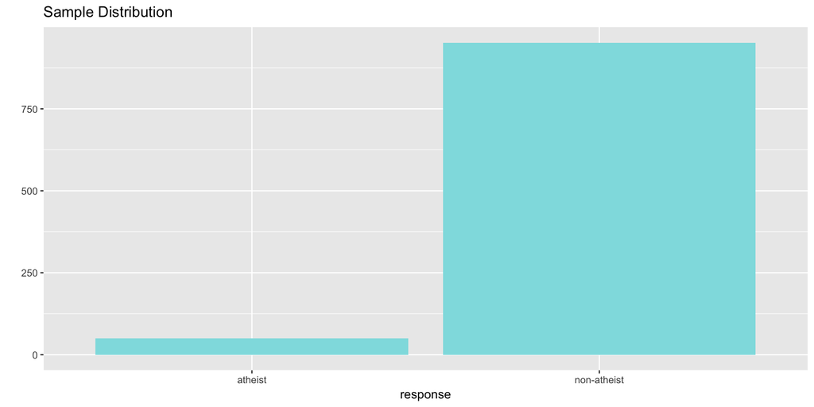

```r
# Compare to
binom::binom.confint(x = 50, n = 1002)
```

```
          method  x    n       mean      lower      upper
1  agresti-coull 50 1002 0.04990020 0.03794568 0.06529272
2     asymptotic 50 1002 0.04990020 0.03641833 0.06338206
3          bayes 50 1002 0.05034895 0.03715065 0.06405466
4        cloglog 50 1002 0.04990020 0.03761110 0.06461097
5          exact 50 1002 0.04990020 0.03726042 0.06526103
6          logit 50 1002 0.04990020 0.03801900 0.06524253
7         probit 50 1002 0.04990020 0.03780467 0.06489964
8        profile 50 1002 0.04990020 0.03755508 0.06454215
9            lrt 50 1002 0.04990020 0.03755222 0.06453384
10     prop.test 50 1002 0.04990020 0.03761982 0.06574456
11        wilson 50 1002 0.04990020 0.03805375 0.06518465
```

```r
# Compare to
prop.test(x = 50, n = 1002, correct = TRUE)
```

```
    1-sample proportions test with continuity correction

data:  50 out of 1002, null probability 0.5
X-squared = 810.18, df = 1, p-value < 2.2e-16
alternative hypothesis: true p is not equal to 0.5
95 percent confidence interval:
 0.03761982 0.06574456
sample estimates:
        p
0.0499002
```

```r
prop.test(x = 50, n = 1002, correct = FALSE)
```

```
    1-sample proportions test without continuity correction

data:  50 out of 1002, null probability 0.5
X-squared = 811.98, df = 1, p-value < 2.2e-16
alternative hypothesis: true p is not equal to 0.5
95 percent confidence interval:
 0.03805375 0.06518465
sample estimates:
        p
0.0499002
```

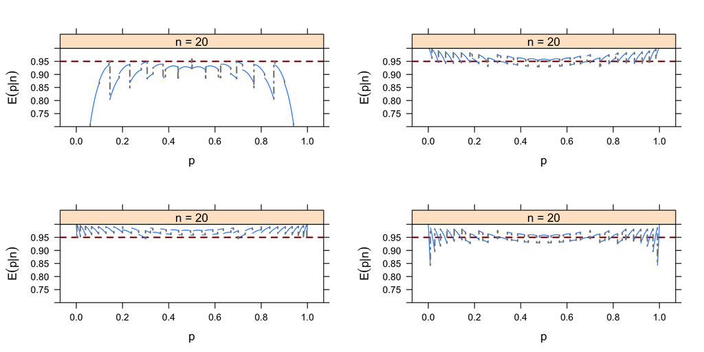

```r
# Some notes:
p1 <- binom::binom.plot(n = 20, method = binom.asymp, np = 2000, ylim = c(0.7, 1))
p2 <- binom::binom.plot(n = 20, method = binom.agresti.coull, np = 2000, ylim = c(0.7, 1))
p3 <- binom::binom.plot(n = 20, method = binom.prop.test, np = 2000, ylim = c(0.7, 1))
p4 <- binom::binom.plot(n = 20, method = binom.wilson, np = 2000, ylim = c(0.7, 1))
gridExtra::grid.arrange(p1, p2, p3, p4, ncol = 2, nrow = 2)
```

Note that since the goal is to construct an interval estimate for a proportion, it is necessary to specify what constitutes a “success”, which here is a response of `atheist`.

Although formal confidence intervals and hypothesis tests don’t show up in the report, suggestions of inference appear at the bottom of page 7: “In general, the error margin for surveys of this kind is $\pm$ 3-5% at 95% confidence.”

**Exercise 2**: Imagine that, after reading a front page story about the latest public opinion poll, a family member asks you, “What is a margin of error?” In one sentence, and ignoring the mechanics behind the calculation, how would you respond in a way that conveys the general concept?

Type your answer to Exercise 2 here and delete this sentence.

8. Based on the R output, what is the margin of error for the estimate of the proportion of the proportion of atheists in US in 2012?
   1. The margin of error for the estimate of the proportion of atheists in the US in 2012 is 0.05.
   2. The margin of error for the estimate of the proportion of atheists in the US in 2012 is 0.025.
   3. The margin of error for the estimate of the proportion of atheists in the US in 2012 is 0.0135.

```r
# Type your code for Question 8 here, and Knit.
```

Type your answer to Question 8 here and delete this sentence.

**Exercise 3**: Using the inference function, calculate confidence intervals for the proportion of atheists in 2012 in two other countries of your choice, and report the associated margins of error. Be sure to note whether the conditions for inference are met. It may be helpful to create new data sets for each of the two countries first and then use these data sets in the `inference` function to construct the confidence intervals.

```r
# Type your code for Exercise 3 here, and Knit.
```

Type your answer for Exercise 3 here and delete this sentence—Answers will vary.

## How does the proportion affect the margin of error?

Imagine you’ve set out to survey 1000 people on two questions: are you female? and are you left-handed? Since both of these sample proportions were calculated from the same sample size, they should have the same margin of error, right? Wrong! While the margin of error does change with sample size, it is also affected by the proportion.

Think back to the formula for the standard error: $SE = \sqrt{p(1-p)/n}$. This is then used in the formula for the margin of error for a 95% confidence interval: $ME = 1.96\times SE = 1.96\times\sqrt{p(1-p)/n}$. Since the population proportion $p$ is in this $ME$ formula, it should make sense that the margin of error is in some way dependent on the population proportion. We can visualize this relationship by creating a plot of $ME$ vs. $p$.

The first step is to make a vector `p` that is a sequence from $0$ to $1$ with each number separated by $0.01$. We can then create a vector of the margin of error (`me`) associated with each of these values of `p` using the familiar approximate formula ($ME = 1.96 \times SE$). Lastly, we plot the two vectors against each other to reveal their relationship.

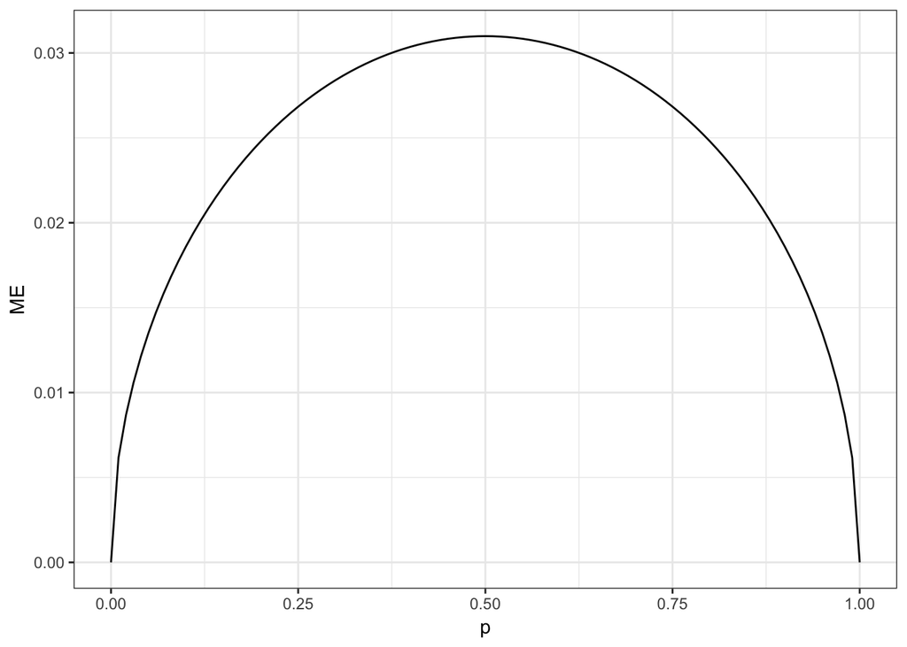

```r
d <- data.frame(p <- seq(0, 1, 0.01))
n <- 1000
d <- d %>%
  mutate(ME = qnorm(0.975)*sqrt(p*(1 - p)/n))
ggplot(d, aes(x = p, y = ME)) +
  geom_line() +
  theme_bw()
```

9. Which of the following is false about the relationship between $p$ and $ME$.
   1. The $ME$ reaches a minimum at $p = 0$.
   2. The $ME$ reaches a minimum at $p = 1$.
   3. The $ME$ is maximized when $p = 0.5$.
   4. The most conservative estimate when calculating a confidence interval occurs when $p$ is set to 1.

Type your answer for Question 9 here and delete this sentence.

The question of atheism was asked by WIN-Gallup International in a similar survey that was conducted in 2005. We assume here that sample sizes have remained the same. Table 4 on page 13 of the report summarizes survey results from 2005 and 2012 for 39 countries.

Answer the following two questions using the `inference` function. As always, write out the hypotheses for any tests you conduct and outline the status of the conditions for inference.

10. True / False: There is convincing evidence that Spain has seen a change in its atheism index between 2005 and 2012.  
    *Hint:* Create a new data set for respondents from Spain. Then use their responses as the first input on the `inference`, and use `year` as the grouping variable.
    1. True
    2. False

```r
# Type your code for Question 10 here, and Knit.
```

Type your answer to Question 10 here and delete this sentence.

11. True / False: There is convincing evidence that the United States has seen a change in its atheism index between 2005 and 2012.
    1. True
    2. False

```r
# Type your code for Question 11 here, and Knit.
```

Type your answer for Question 11 here and delete this sentence.

12. If in fact there has been no change in the atheism index in the countries listed in Table 4, in how many of those countries would you expect to detect a change (at a significance level of 0.05) simply by chance?  
    *Hint:* Type 1 error.
    1. 0
    2. 1
    3. 1.95
    4. 5

```r
# Type your code for Question 12 here, and Knit.
```

Type your answer for Question 12 here and delete this sentence.

13. Suppose you’re hired by the local government to estimate the proportion of residents who attend a religious service on a weekly basis. According to the guidelines, the estimate must have a margin of error no greater than 1% with 95% confidence. You have no idea what to expect for $p$. How many people would you have to sample to ensure that you are within the guidelines?  
    *Hint:* Refer to your plot of the relationship between $p$ and margin of error. Do not use the data set to answer this question.
    1. 2401 people
    2. At least 2401 people
    3. 9604 people
    4. At least 9604 people

```r
# Type your code for Question 13 here, and Knit.
```

Type your answer to Question 13 here and delete this sentence.

## New Problem

```r
europe <- atheism %>%
  filter(nationality == "Austria" | nationality == "Bulgaria" |
           nationality == "Finaland" | nationality == "France" |
           nationality == "Germany" | nationality == "Netherlands" |
           nationality == "Poland" | nationality == "Romania" |
           nationality == "Spain" | nationality == "Switzerland")

europe$nationality <- droplevels(europe$nationality)
T2 <- xtabs(~response + nationality + year, data = europe)
T2
```

```
, , year = 2005

             nationality
response      Austria Bulgaria France Germany Netherlands Poland Romania
  atheist         100       50    234      50          35     10      10
  non-atheist     903      941   1437     452         470    510    1040
             nationality
response      Spain Switzerland
  atheist       115          35
  non-atheist  1031         472

, , year = 2012

             nationality
response      Austria Bulgaria France Germany Netherlands Poland Romania
  atheist         100       19    485      75          71     26      10
  non-atheist     902      987   1203     427         438    499    1029
             nationality
response      Spain Switzerland
  atheist       103          46
  non-atheist  1042         467
```

```r
A2005 <- T2[, , 1]
A2012 <- T2[, , 2]
A2005
```

```
             nationality
response      Austria Bulgaria France Germany Netherlands Poland Romania
  atheist         100       50    234      50          35     10      10
  non-atheist     903      941   1437     452         470    510    1040
             nationality
response      Spain Switzerland
  atheist       115          35
  non-atheist  1031         472
```

```r
A2012
```

```
             nationality
response      Austria Bulgaria France Germany Netherlands Poland Romania
  atheist         100       19    485      75          71     26      10
  non-atheist     902      987   1203     427         438    499    1029
             nationality
response      Spain Switzerland
  atheist       103          46
  non-atheist  1042         467
```

```r
prop.table(A2005, 2)
```

```
             nationality
response         Austria   Bulgaria     France    Germany Netherlands
  atheist     0.09970090 0.05045409 0.14003591 0.09960159  0.06930693
  non-atheist 0.90029910 0.94954591 0.85996409 0.90039841  0.93069307
             nationality
response          Poland    Romania      Spain Switzerland
  atheist     0.01923077 0.00952381 0.10034904  0.06903353
  non-atheist 0.98076923 0.99047619 0.89965096  0.93096647
```

```r
prop.table(A2012, 2)
```

```
             nationality
response          Austria    Bulgaria      France     Germany Netherlands
  atheist     0.099800399 0.018886680 0.287322275 0.149402390 0.139489194
  non-atheist 0.900199601 0.981113320 0.712677725 0.850597610 0.860510806
             nationality
response           Poland     Romania       Spain Switzerland
  atheist     0.049523810 0.009624639 0.089956332 0.089668616
  non-atheist 0.950476190 0.990375361 0.910043668 0.910331384
```

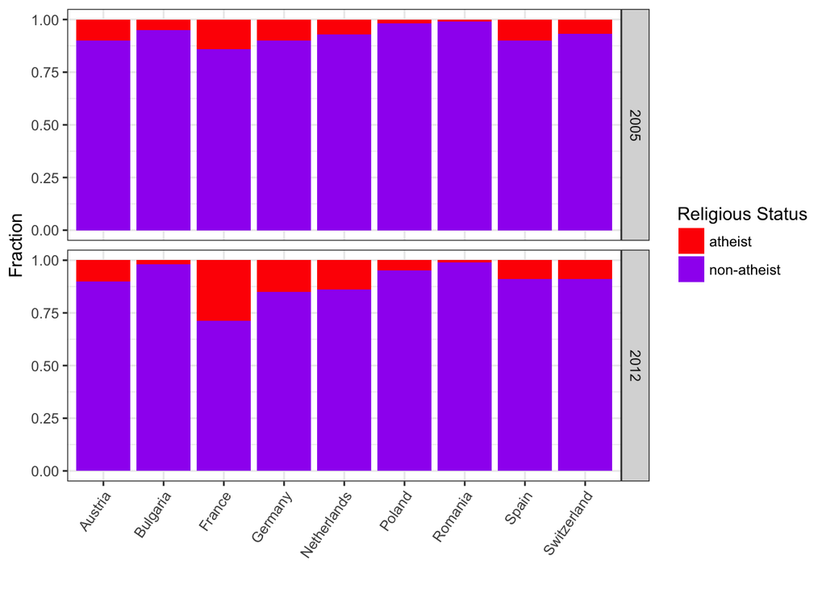

```r
# Graph now
ggplot(data = europe, aes(x = nationality, fill = response)) +
  geom_bar(position = "fill") +
  theme_bw() +
  labs(x= "Year", y = "Fraction") +
  scale_fill_manual(values = c("red", "purple"), name = "Religious Status") +
  facet_grid(year ~ .) +
  theme(axis.text.x  = element_text(angle = 55, hjust = 1.0)) +
  labs(x= "")
```

**Question:** Can you arrange the barplots so that `non-atheist` are arranged in descending order for 2012?

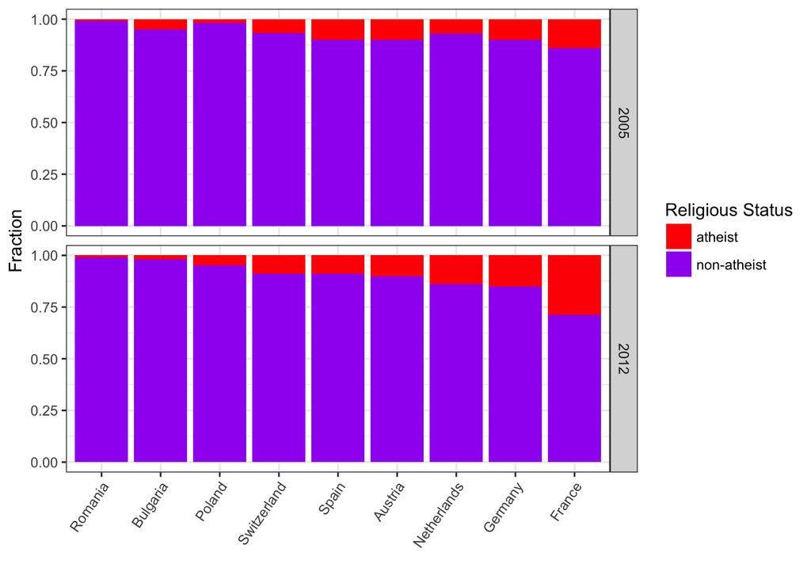

```r
# Rearranging the factor levels
europe$nationality <- factor(europe$nationality,
                           levels = c("Romania", "Bulgaria", "Poland",
                                      "Switzerland", "Spain", "Austria",
                                      "Netherlands", "Germany", "France"))


ggplot(data = europe, aes(x = nationality, fill = response)) +
  geom_bar(position = "fill") +
  theme_bw() +
  labs(x= "Year", y = "Fraction") +
  scale_fill_manual(values = c("red", "purple"), name = "Religious Status") +
  facet_grid(year ~ .) +
  theme(axis.text.x  = element_text(angle = 55, hjust = 1.0)) +
  labs(x= "")
```

```r
eu12 <- europe %>%
  filter(year == 2012)
head(eu12)
```

```
# A tibble: 6 × 3
  nationality    response  year
       <fctr>      <fctr> <int>
1     Austria non-atheist  2012
2     Austria non-atheist  2012
3     Austria non-atheist  2012
4     Austria non-atheist  2012
5     Austria non-atheist  2012
6     Austria non-atheist  2012
```

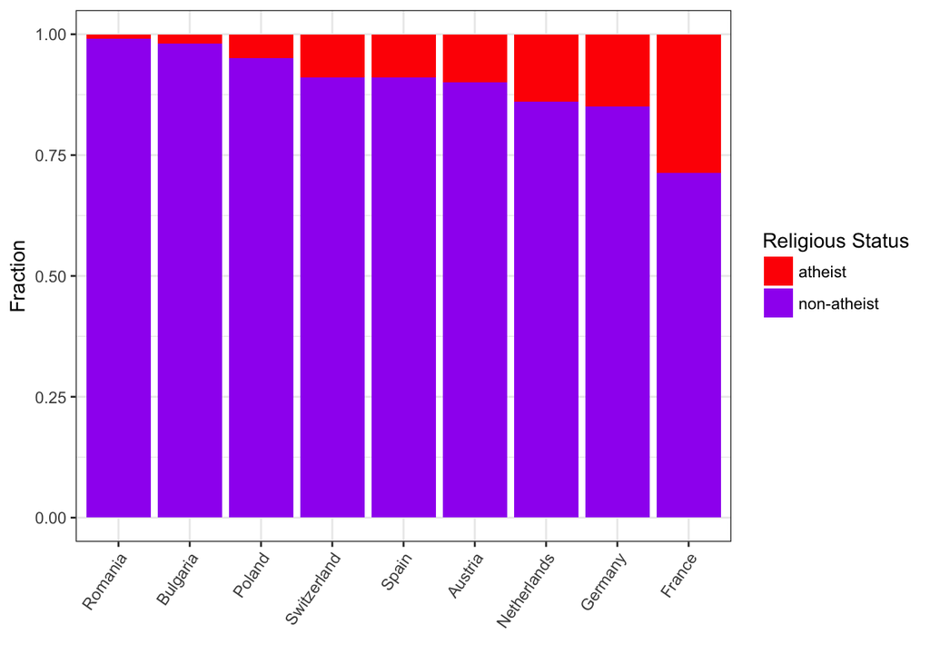

```r
ggplot(data = eu12, aes(x = nationality, fill = response)) +
  geom_bar(position = "fill") +
  theme_bw() +
  labs(x= "Year", y = "Fraction") +
  scale_fill_manual(values = c("red", "purple"), name = "Religious Status") +
  theme(axis.text.x  = element_text(angle = 55, hjust = 1.0)) +
  labs(x= "")
```

```r
T4 <- xtabs(~ response + nationality, data = eu12)
T4
```

```
             nationality
response      Romania Bulgaria Poland Switzerland Spain Austria
  atheist          10       19     26          46   103     100
  non-atheist    1029      987    499         467  1042     902
             nationality
response      Netherlands Germany France
  atheist              71      75    485
  non-atheist         438     427   1203
```

```r
chisq.test(T4)
```

```
    Pearson's Chi-squared test

data:  T4
X-squared = 724.09, df = 8, p-value < 2.2e-16
```

```r
# Post hoc tests
library(fifer)
chisq.post.hoc(T4, control = "bonferroni", popsInRows  = FALSE)
```

```
Adjusted p-values used the bonferroni method.
```

```
                    comparison  raw.p  adj.p
1         Romania vs. Bulgaria 0.0922 1.0000
2           Romania vs. Poland 0.0000 0.0001
3      Romania vs. Switzerland 0.0000 0.0000
4            Romania vs. Spain 0.0000 0.0000
5          Romania vs. Austria 0.0000 0.0000
6      Romania vs. Netherlands 0.0000 0.0000
7          Romania vs. Germany 0.0000 0.0000
8           Romania vs. France 0.0000 0.0000
9          Bulgaria vs. Poland 0.0012 0.0439
10    Bulgaria vs. Switzerland 0.0000 0.0000
11          Bulgaria vs. Spain 0.0000 0.0000
12        Bulgaria vs. Austria 0.0000 0.0000
13    Bulgaria vs. Netherlands 0.0000 0.0000
14        Bulgaria vs. Germany 0.0000 0.0000
```

[output cut: 22 more lines]